# NBA球風分析(簡易版)

## 此分析取材自各賽季排名前50名球員之平均，因此僅供參考，不能代表所有球員

# 讀取檔案

```r
filenames <- list.files("C:/Users/user/Desktop/week_6,7,8/data/3PA", pattern="*.csv",full.names = T)
filenames1 <- list.files("C:/Users/user/Desktop/week_6,7,8/data/3P_PCT", pattern="*.csv",full.names = T)
filenames2 <- list.files("C:/Users/user/Desktop/week_6,7,8/data/OREB", pattern="*.csv",full.names = T)
filenames3 <- list.files("C:/Users/user/Desktop/week_6,7,8/data/PTS_MIN", pattern="*.csv",full.names = T)
filenames4 <- list.files("C:/Users/user/Desktop/week_6,7,8/data/DREB", pattern="*.csv",full.names = T)
name <- gsub("C:/Users/user/Desktop/week_6,7,8/data/3PA/","",filenames)
name1 <- gsub("C:/Users/user/Desktop/week_6,7,8/data/3P_PCT/","",filenames1)
年 <- gsub(".csv","",name)
年_三分命中率 <- gsub(".csv","",name1)
read <-  function(csv){
  read.csv( csv, stringsAsFactors = FALSE)
}
Three_PA <- lapply(filenames, read)#class(Three_PA)=list
Three_PCT <- lapply(filenames1, read)#檔案數不同
OREB <- lapply(filenames2, read)
PTS_MIN<- lapply(filenames3, read)
DREB <- lapply(filenames4, read)
file_len <- length(Three_PA)#共39個檔案
file_len1 <- length(Three_PCT)#共24個檔案
```

# 平均三分球出手數

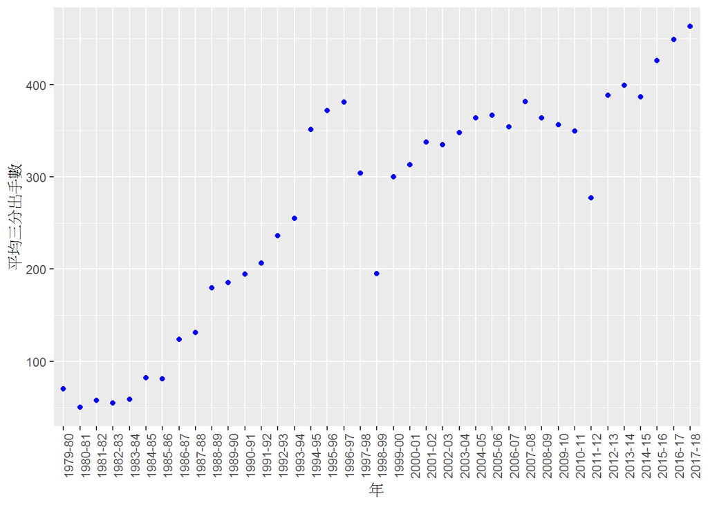

```r
平均三分出手數 <- list()
for(i in c(1:file_len)){
  # 轉換資料型態
  ThreePA <- Three_PA[[i]]
  len <- length(ThreePA$FG3A)
  sum <- sum(ThreePA$FG3A)
  平均三分出手數[i] <- sum/len
}
平均三分出手數 <- unlist(平均三分出手數)
Data <- data.frame(年=年,平均三分出手數=平均三分出手數,stringsAsFactors = F)
# 繪製折線圖
ggplot(Data, aes(年,平均三分出手數)) + geom_point(stat = "identity", color = "blue") +theme(axis.text.x = element_text(angle = 90))
```

## 從此圖中可以看出有一條很明顯的趨勢線，證明從1979-80賽季到2017-18賽季，三分球的出手次數有明顯增長，從而也可以推論出球風漸漸朝向三分投射的發展

# 三分球平均命中率

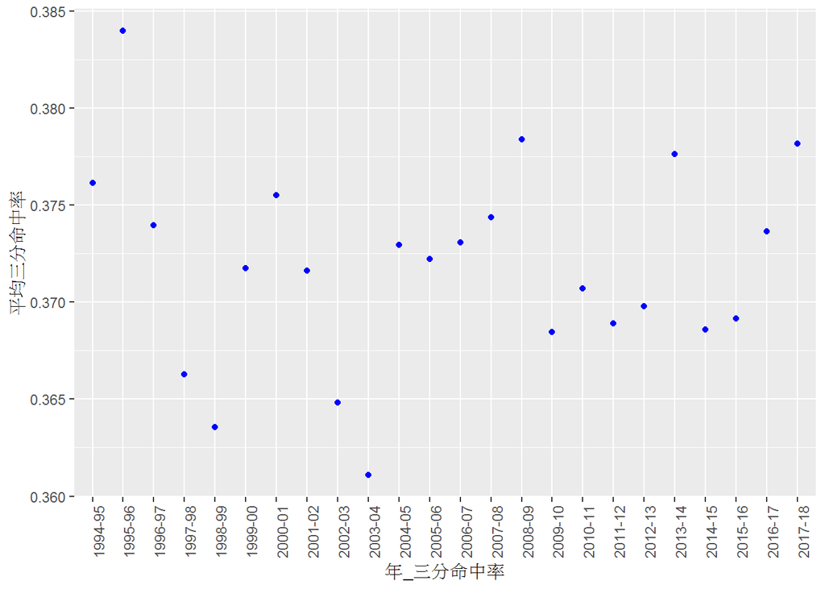

```r
平均三分命中率 <- list()
for(i in c(1:file_len1)){
  # 轉換資料型態
  ThreePCT <- Three_PCT[[i]]
  len <- length(ThreePCT$FG3_PCT)
  sum <- sum(ThreePCT$FG3_PCT)
  平均三分命中率[i] <- sum/len
}
平均三分命中率 <- unlist(平均三分命中率)
Data1 <- data.frame(年_三分命中率=年_三分命中率,平均三分命中率=平均三分命中率,stringsAsFactors = F)
ggplot(Data1, aes(年_三分命中率,平均三分命中率)) + geom_point(stat = "identity", color = "blue") +theme(axis.text.x = element_text(angle = 90))
```

## 這張圖的趨勢非常的不明顯，理由是資料的缺失。可以從年分中看出，從1979-80賽季到2017-18賽季中，有許多季是資料不充足的，因此這項大致上不具參考性。但是若只看近幾年，可以看出後段有個向上的趨勢，可以稍稍佐證因為訓練技術的提升而提升三分命中率的傳言。

# 進攻籃板

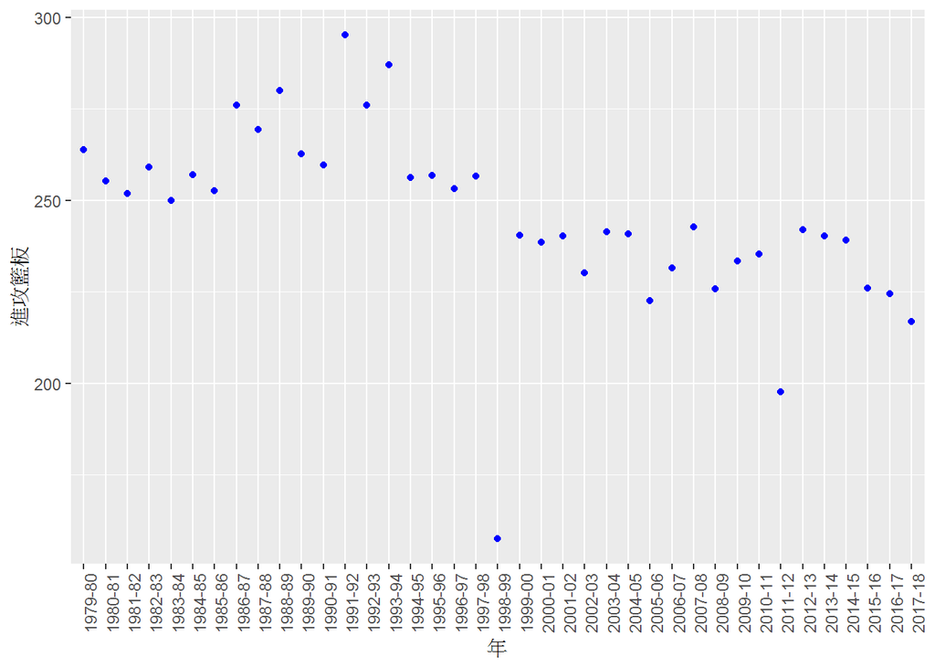

```r
進攻籃板 <- list()
for(i in c(1:file_len)){
  # 轉換資料型態
  OREB_V <- OREB[[i]]
  len <- length(OREB_V$OREB)
  sum <- sum(OREB_V$OREB)
  進攻籃板[i] <- sum/len
}
進攻籃板 <- unlist(進攻籃板)
Data1 <- data.frame(年=年,進攻籃板=進攻籃板,stringsAsFactors = F)
ggplot(Data1, aes(年,進攻籃板)) + geom_point(stat = "identity", color = "blue") +theme(axis.text.x = element_text(angle = 90))
```

## 這張圖可以看出進攻籃板有著些微的下滑趨勢，但我認為這個趨勢並未過於明顯，因此我認為進攻籃板不具有參考性

# 防守籃板

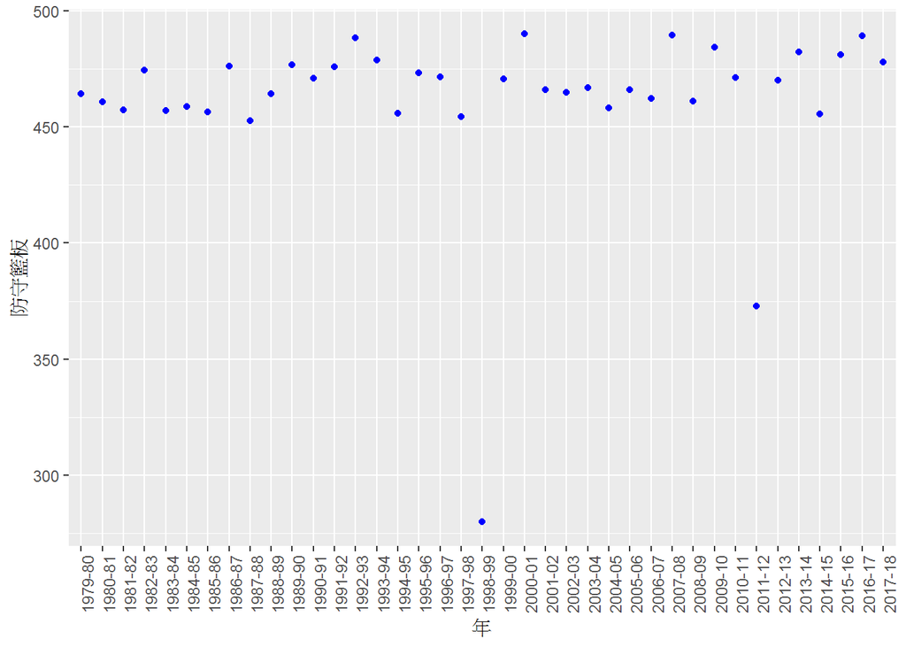

```r
防守籃板 <- list()
for(i in c(1:file_len)){
  # 轉換資料型態
  DREB_V <- DREB[[i]]
  len <- length(DREB_V$DREB)
  sum <- sum(DREB_V$DREB)
  防守籃板[i] <- sum/len
}
防守籃板 <- unlist(防守籃板)
Data1 <- data.frame(年=年,防守籃板=防守籃板,stringsAsFactors = F)
ggplot(Data1, aes(年,防守籃板)) + geom_point(stat = "identity", color = "blue") +theme(axis.text.x = element_text(angle = 90))
```

## 防守籃板的趨勢甚至比進攻籃板來的小，因此也不具參考性

# 平均得分效率

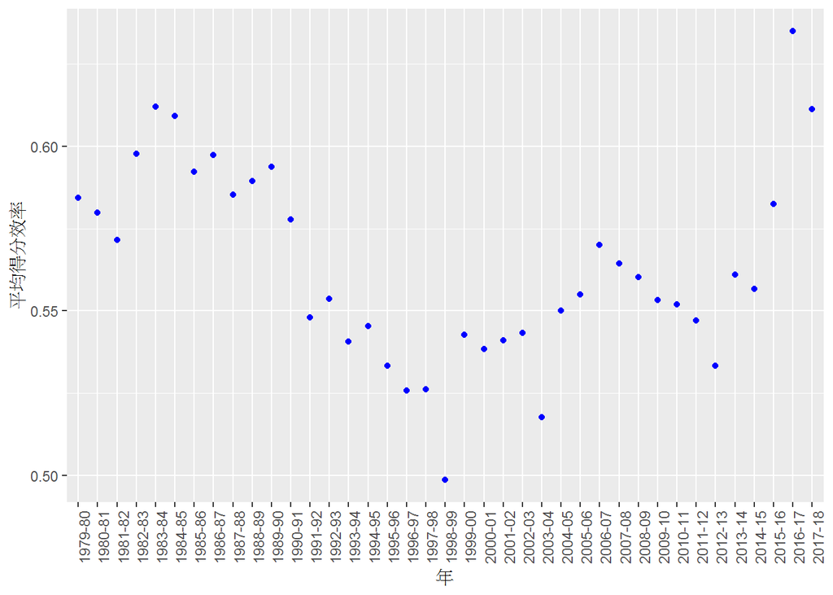

```r
平均得分效率 <- list()
for(i in c(1:file_len)){
  # 轉換資料型態
  PTSMIN <- PTS_MIN[[i]]
  len <- length(PTSMIN$PPG)
  sum <- sum(PTSMIN$PPG)
  平均得分效率[i] <- sum/len
}
平均得分效率 <- unlist(平均得分效率)
Data1 <- data.frame(年=年,平均得分效率=平均得分效率,stringsAsFactors = F)
ggplot(Data1, aes(年,平均得分效率)) + geom_point(stat = "identity", color = "blue") +theme(axis.text.x = element_text(angle = 90))
```